# R Notebook

First of all we import the necessary libraries for the causality study that will follow.

```r
library(dplyr)       # Data manipulation (0.8.0.1)
library(fBasics)     # Summary statistics (3042.89)
```

```r
library(corrplot)    # Correlations (0.84)
library(psych)       # Correlation p-values (1.8.12)
library(grf)         # Generalized random forests (0.10.2)

library(rpart)       # Classification and regression trees, or CART (4.1-13)

library(rpart.plot)  # Plotting trees (3.0.6)

library(treeClust)   # Predicting leaf position for causal trees (1.1-7)
library(car)         # linear hypothesis testing for causal tree (3.0-2)
library(devtools)    # Install packages from github (2.0.1)
library(readr)       # Reading csv files (1.3.1)

library(tidyr)       # Database operations (0.8.3)

library(tibble)      # Modern alternative to data frames (2.1.1)

library(knitr)       # RMarkdown (1.21)

library(kableExtra)  # Prettier RMarkdown (1.0.1)
library(ggplot2)     # general plotting tool (3.1.0)
library(haven)       # read stata files (2.0.0)

library(aod)         # hypothesis testing (1.3.1)

library(evtree)      # evolutionary learning of globally optimal trees (1.0-7)
library(causalTree)
library(causalToolbox)
```

We now read the data set of interest for the pursuit of the study. The present dataset has been treated already, there are no missing values nor NaN in the table.

```r
# df <- read.csv("tabela_amelia5.csv", na.strings = c("NA", "ND", "NF", "NR","")  )
#outcome_variable_name <- "Y"
#treatment_variable_name <- "W"
#covariate_names <- c(  "Anticoagulant.therapy","Antiplatelet.therapy", "GCS.init",
#"GCS.motor.init","Pupil.anomaly.ph","Osmotherapy.ph",   "Improv.anomaly.osmo","Cardiac.arrest.ph","SBP.ph","DBP.ph",      "HR.ph",  "SBP.ph.min",   "DBP.ph.min",   "HR.ph.max",    "Cristalloid.volume",   "Colloid.volume","HemoCue.init","Delta.hemoCue","Vasopressor.therapy",  "SpO2.ph.min",  "Medcare.time.ph",  "GCS",  "GCS.motor",    "Pupil.anomaly",    "TCD.PI.max",   "FiO2", "Neurosurgery.day0",    "IGS.II",   "Temperature.min",  "W",    "TBI",  "Osmotherapy",  "IICP", "EVD",  "Decompressive.craniectomy",    "Y",    "AIS.head", "AIS.face", "AIS.external", "ISS",  "Shock.index.ph",   "Delta.shock.index")

df <- read.csv("data_correct.csv") #, na.strings = c("NA", "ND", "NF", "NR","")  )
outcome_variable_name <- "Y"
treatment_variable_name <- "W"
covariate_names <- c("SBP.ph","DBP.ph",
                     "HR.ph","Shock.index.ph","Delta.shock.index",
"Cristalloid.volume","Colloid.volume","HemoCue.init","Delta.hemoCue","SpO2.ph.min",
"Vasopressor.therapy","AIS.external","Cardiac.arrest.ph")

summary(df)
```

```
##       X.1             X        Trauma.center        SBP.ph
##  Min.   :   1   Min.   :   1   Min.   : 1.000   Min.   :-4.52580
##  1st Qu.:2068   1st Qu.:2068   1st Qu.: 1.000   1st Qu.:-0.51716
##  Median :4135   Median :4135   Median : 3.000   Median : 0.06522
##  Mean   :4135   Mean   :4135   Mean   : 4.184   Mean   :-0.01808
##  3rd Qu.:6202   3rd Qu.:6202   3rd Qu.: 5.000   3rd Qu.: 0.58935
##  Max.   :8269   Max.   :8269   Max.   :21.000   Max.   : 3.73416
##      DBP.ph             HR.ph           Shock.index.ph
##  Min.   :-4.45135   Min.   :-3.616841   Min.   :-5.12784
##  1st Qu.:-0.54590   1st Qu.:-0.610767   1st Qu.:-0.57150
##  Median : 0.09081   Median :-0.003148   Median :-0.10305
##  Mean   :-0.01636   Mean   :-0.007776   Mean   : 0.00132
##  3rd Qu.: 0.63067   3rd Qu.: 0.613167   3rd Qu.: 0.44171
##  Max.   : 4.29121   Max.   : 4.057278   Max.   :23.75762
##  Delta.shock.index    Cristalloid.volume Colloid.volume
##  Min.   :-26.588152   Min.   :-3.40334   Min.   :-3.55770
##  1st Qu.: -0.370470   1st Qu.:-0.49750   1st Qu.:-0.25875
##  Median :  0.064329   Median :-0.28114   Median :-0.25875
##  Mean   :  0.009022   Mean   :-0.03361   Mean   :-0.02579
##  3rd Qu.:  0.435672   3rd Qu.: 0.36991   3rd Qu.:-0.25875
##  Max.   : 19.765270   Max.   : 9.84302   Max.   :11.82991
##   HemoCue.init      Delta.hemoCue        SpO2.ph.min
##  Min.   :-6.44098   Min.   :-5.310144   Min.   :-9.19870
##  1st Qu.:-0.59333   1st Qu.:-0.599317   1st Qu.:-0.13232
##  Median : 0.16734   Median :-0.054188   Median : 0.23786
##  Mean   : 0.02169   Mean   :-0.002401   Mean   :-0.01477
##  3rd Qu.: 0.69030   3rd Qu.: 0.581797   3rd Qu.: 0.44524
##  Max.   : 4.25363   Max.   : 7.123350   Max.   : 6.36676
##  Vasopressor.therapy  AIS.external    Cardiac.arrest.ph       Y
##  Min.   :0.000       Min.   :0.0000   Min.   :1.000     Min.   :0.0000
##  1st Qu.:0.000       1st Qu.:0.0000   1st Qu.:1.000     1st Qu.:0.0000
##  Median :0.000       Median :0.0000   Median :1.000     Median :0.0000
##  Mean   :0.177       Mean   :0.1622   Mean   :1.062     Mean   :0.1993
##  3rd Qu.:0.000       3rd Qu.:0.0000   3rd Qu.:1.000     3rd Qu.:0.0000
##  Max.   :1.000       Max.   :5.0000   Max.   :2.000     Max.   :1.0000
##        W             p.logistic       propensity.score.gbm
##  Min.   :0.00000   Min.   :0.001887   Min.   :0.01321
##  1st Qu.:0.00000   1st Qu.:0.018791   1st Qu.:0.02058
##  Median :0.00000   Median :0.033754   Median :0.02993
##  Mean   :0.08296   Mean   :0.082961   Mean   :0.08297
##  3rd Qu.:0.00000   3rd Qu.:0.076785   3rd Qu.:0.06669
##  Max.   :1.00000   Max.   :0.999993   Max.   :0.96980
```

```r
all_variables_names <- c(outcome_variable_name, treatment_variable_name, covariate_names)
df <- df[, which(names(df) %in% all_variables_names)]

train_fraction <- 0.80  # Use train_fraction % of the dataset to train our models
n <- dim(df)[1]

train_idx <- sample.int(n, replace=F, size=floor(n*train_fraction))
df_train <- df[train_idx,]
df_test <- df[-train_idx,]
```

Detecting heterogeneous treatment effects, i.e., differential effects of an intervention for certain subgroups of the population, can be very valuable in many areas of research. Causal trees provide a data-driven approach to partitioning the data into subgroups that differ by the magnitude of their treatment effects. Much like decision trees, which partition the covariate space by finding subgroups with similar *outcomes*, causal trees find subgroups with *similar treatment effects*. Moreover, even though this is an adaptive method, these subgroups do not need to be specified prior to the experiment.

In order to ensure valid estimates of the treatment effect within each subgroup, a sample-splitting approach is used - **honesty**: a method is honest if it uses one subset of the data to estimate the model parameters, and a different subset to produce estimates given these estimated parameters. In the context of causal trees, honesty is one of the assumptions required to produce unbiased and asymptotically normal estimates of the treatment effect.

#### Step 1: Split the dataset

As we just explained, honesty requires us to separate different subsets of our training data for model selection and prediction.

- `df_split`: the *splitting sample*, used to build the tree
- `df_est`: the *estimation sample*, used to compute the average treatment effect in each leaf

```r
split_size <- floor(nrow(df_train) * 0.7)
split_idx <- sample(nrow(df_train), replace=FALSE, size=split_size)

# Make the splits
df_split <- df_train[split_idx,]
df_est <- df_train[-split_idx,]
fmla_ct <- paste("factor(Y) ~", paste(covariate_names, collapse = " + "))

ct_unpruned <- honest.causalTree(
  formula=fmla_ct,            # Define the model
  data=df_split,              # Subset used to create tree structure
  est_data=df_est,            # Which data set to use to estimate effects

  treatment=df_split$W,       # Splitting sample treatment variable
  est_treatment=df_est$W,     # Estimation sample treatment variable

  split.Rule="CT",            # Define the splitting option
  cv.option="TOT",            # Cross validation options

  split.Honest=TRUE,          # Use honesty when splitting
  cv.Honest=TRUE,             # Use honesty when performing cross-validation

  minsize=17,                 # Min. number of treatment and control cases in each leaf
  HonestSampleSize=nrow(df_est)) # Num obs used in estimation after building the tree
```

```
## [1] 2
## [1] "CT"
```

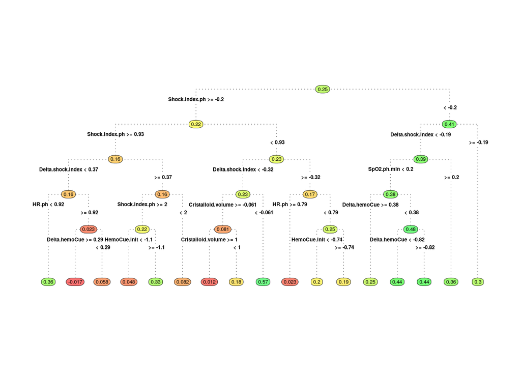

```r
rpart.plot(ct_unpruned,type = 4, extra = 0, branch.lty = 3, box.palette = "RdYlGn")
```

```r
#part.plot(ct_unpruned, type = 4, varlen = 0, faclen = 0, fallen.leaves = TRUE)
```

#### Cross-validate

We must prune the tree by cross-validation to avoid overfitting. The honest cross-validation method selected above penalizes an estimate of the variance in the treatment effects estimates across leaves, and this estimate is computed using the estimation sample.

```r
# Table of cross-validated values by tuning parameter.
ct_cptable <- as.data.frame(ct_unpruned$cptable)

# Obtain optimal complexity parameter to prune tree.
selected_cp <- which.min(ct_cptable$xerror)
optim_cp_ct <- ct_cptable[selected_cp, "CP"]

# Prune the tree at optimal complexity parameter.
ct_pruned <- prune(tree=ct_unpruned, cp=optim_cp_ct)
```

#### Predict point estimates (on estimation sample)

To predict the treatment effect on the estimation sample, use the function `predict` as below.

```r
tauhat_ct_est <- predict(ct_pruned, newdata=df_est)

paste(mean(tauhat_ct_est))
```

```
## [1] "0.2535585839656"
```

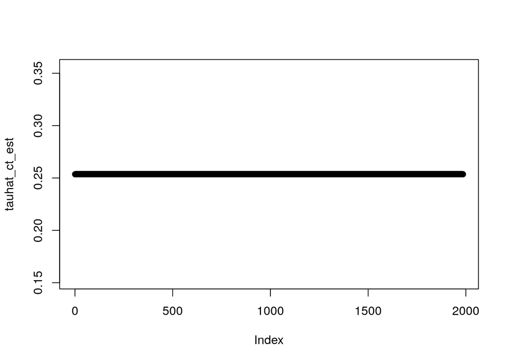

```r
plot(tauhat_ct_est)
```

#### Predict point estimates (on test set)

To predict the treatment effect on a new, entirely unseen data, use the function `predict` as below.

```r
tauhat_ct_test <- predict(ct_pruned, newdata=df_test)
paste(mean(tauhat_ct_test))
```

```
## [1] "0.2535585839656"
```

### Assessing heterogeneity

A natural place to begin is by ploting the (pruned) tree.

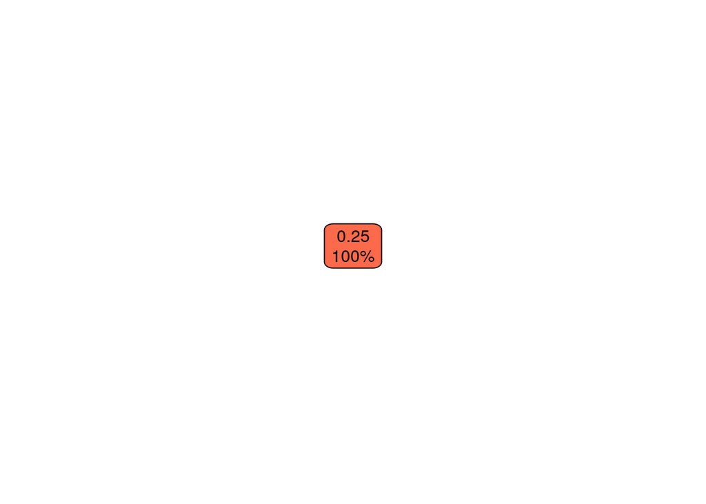

```r
rpart.plot(
  x=ct_pruned,        # Pruned tree
  type=3,             # Draw separate split labels for the left and right directions
  fallen=TRUE,        # Position the leaf nodes at the bottom of the graph
  leaf.round=1,       # Rounding of the corners of the leaf node boxes
  extra=100,          # Display the percentage of observations in the node
  branch=.1,          # Shape of the branch lines
  box.palette="RdBu") # Palette for coloring the node
```

********************************

## Estimating the Treatment with Causal Forests

We start by training a pilot random forest on all the features, and then train a second forest on only those features that saw a reasonable number of splits in the first forest. This enables the second forest to make better splits and use most useful features.

```r
Y <- df[, which(names(df) %in% outcome_variable_name)]
W <- df[, which(names(df) %in% treatment_variable_name)]
x_covariate_names <- c("SBP.ph","DBP.ph",
                     "HR.ph","Shock.index.ph","Delta.shock.index",
"Cristalloid.volume","Colloid.volume","HemoCue.init","Delta.hemoCue","SpO2.ph.min",
"Vasopressor.therapy","AIS.external","Cardiac.arrest.ph")

X <- df[, which(names(df) %in% x_covariate_names)]
X <- data.frame(lapply(X, function(x) as.numeric(as.character(x))))

y_forest <- regression_forest(X, Y)
y_hat <- predict(y_forest)$predictions

w_forest <- regression_forest(X, W)
w_hat <- predict(w_forest)$predictions

cf_raw <- causal_forest(X, Y, W,
                        Y.hat = y_hat, W.hat = w_hat)

varimp <- variable_importance(cf_raw)

selected_id <- which(varimp > mean(varimp))

cf <- causal_forest(X[,selected_id], Y, W,
                    Y.hat = y_hat, W.hat = w_hat,
                    tune.parameters = TRUE)
tau_hat <- predict(cf)$predictions

head(tau_hat)
```

```
## [1] 0.07928459 0.18703544 0.18950817 0.17050152 0.16960904 0.16041280
```

We call here the average treatment function (from the grf package).

```r
ATE <- average_treatment_effect(cf)
paste( " 9 5 % CI for the ATE : " , round ( ATE [1] , 3 ) ,
" +/ - " , round ( qnorm (0.975) * ATE [2] , 3 ))
```

```
## [1] " 9 5 % CI for the ATE :  0.173  +/ -  0.054"
```

Histogram of out-of-bag CATE estimates from a causal forest trained above:

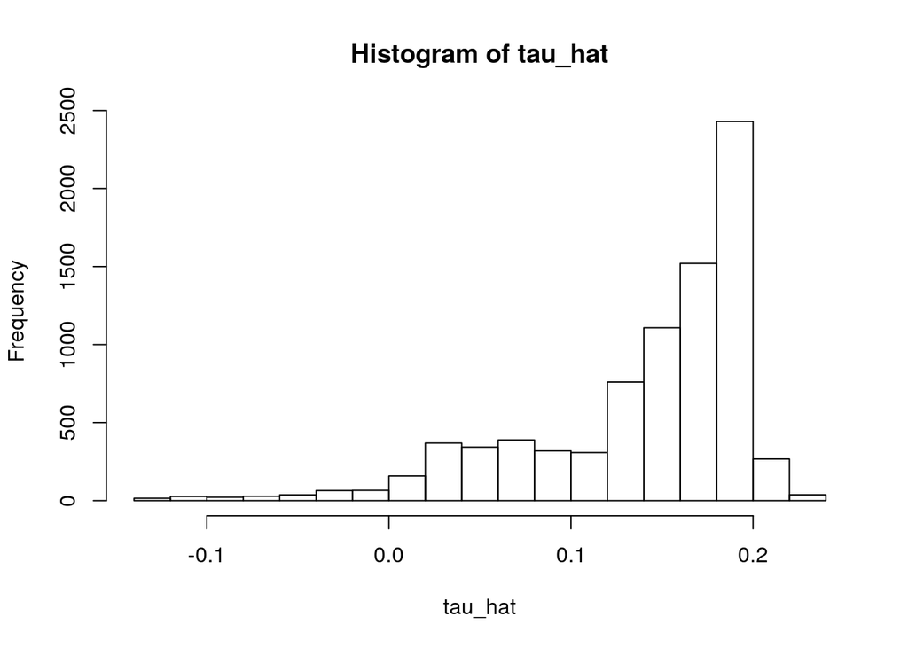

```r
hist(tau_hat)
```

In order to test the heterogeneity learned we can compare the out-of-bag CATE estimates (tau_hat) are above or below the median CATE estimates, and then we estimate the ATE in these two subgroups separately.

```r
# Compare regions with high and low estimated CATEs

high_effect <- tau_hat > median(tau_hat)
ate_high <- average_treatment_effect(cf, subset = high_effect)
ate_low <- average_treatment_effect(cf, subset = !high_effect)
paste( " 9 5 % CI for the ATE : " , round ( ate_high[1] - ate_low[1] , 3 ) ,
" +/ - " , round ( qnorm (0.975) * sqrt(ate_high[2]^2 + ate_low[2]^2) , 3 ))
```

```
## [1] " 9 5 % CI for the ATE :  0.127  +/ -  0.126"
```

The second coefficient of the regression can be interpreted as a measure of the quality of the estimates of treatment heterogeneity. Formally: the p-value for the second coefficient will be used to test the hypothesis that the causal forest succeeded in finding heterogeneity.

```r
test_calibration(cf)
```

```
##
## Best linear fit using forest predictions (on held-out data)
## as well as the mean forest prediction as regressors, along
## with one-sided heteroskedasticity-robust (HC3) SEs:
##
##                                Estimate Std. Error t value    Pr(>t)
## mean.forest.prediction          1.09852    0.17901  6.1368 4.405e-10 ***
## differential.forest.prediction  0.97116    0.25379  3.8267 6.543e-05 ***
## ---
## Signif. codes:  0 '***' 0.001 '**' 0.01 '*' 0.05 '.' 0.1 ' ' 1
```